# Practica8

### Bank Marketing Data Set

Los datos utilizados para esta práctica se pueden descargar del siguiente link. https://archive.ics.uci.edu/ml/datasets/bank+marketing

A continuación se cargan las librerías necesarias para el primer análisis

```python
import os, sys
import numpy as np
import pandas as pd
import pandas_profiling   ####Verificar que esté instalada. Si no está instalada, se puede utilziar el comando conda install -c conda-forge pandas-profiling --y
from IPython.display import Image
from matplotlib import pyplot as plt

from sklearn.preprocessing import StandardScaler
from sklearn.model_selection import train_test_split
from sklearn import metrics
from sklearn.metrics import f1_score, roc_auc_score
from sklearn.linear_model import LogisticRegression
from sklearn.ensemble import RandomForestClassifier
from sklearn.model_selection import GridSearchCV   #####Revisar esta librería.
from sklearn.neural_network import MLPClassifier

from sklearn.tree import DecisionTreeClassifier
from sklearn.metrics import accuracy_score
from sklearn import tree

from sklearn.metrics import confusion_matrix
from sklearn.metrics import recall_score
from sklearn.metrics import precision_score
from sklearn.metrics import classification_report
from sklearn.ensemble import GradientBoostingClassifier

from sklearn.externals.six import StringIO
from IPython.display import Image
from sklearn.tree import export_graphviz
import pydotplus
```

### Configuración del directorio y lectura de los datos

```python
%cd C:\Users\USUARIO\Documents\monitoria_marketing\bank-additional
```

```
C:\Users\USUARIO\Documents\monitoria_marketing\bank-additional
```

```python
##Importante, el archivo no está seoarada por comas, si no por punto y coma
data=pd.read_csv('bank-additional-full.csv', sep=";")
```

A continnuación, se detalla las primeras filas del dataframe, con el fin de verificar que el archivo esté correctamente cargado

```python
data.head()
```

|  | age | job | marital | education | default | housing | loan | contact | month | day_of_week | ... | campaign | pdays | previous | poutcome | emp.var.rate | cons.price.idx | cons.conf.idx | euribor3m | nr.employed | y |
| --- | --- | --- | --- | --- | --- | --- | --- | --- | --- | --- | --- | --- | --- | --- | --- | --- | --- | --- | --- | --- | --- |
| 0 | 56 | housemaid | married | basic.4y | no | no | no | telephone | may | mon | ... | 1 | 999 | 0 | nonexistent | 1.1 | 93.994 | -36.4 | 4.857 | 5191.0 | no |
| 1 | 57 | services | married | high.school | unknown | no | no | telephone | may | mon | ... | 1 | 999 | 0 | nonexistent | 1.1 | 93.994 | -36.4 | 4.857 | 5191.0 | no |
| 2 | 37 | services | married | high.school | no | yes | no | telephone | may | mon | ... | 1 | 999 | 0 | nonexistent | 1.1 | 93.994 | -36.4 | 4.857 | 5191.0 | no |
| 3 | 40 | admin. | married | basic.6y | no | no | no | telephone | may | mon | ... | 1 | 999 | 0 | nonexistent | 1.1 | 93.994 | -36.4 | 4.857 | 5191.0 | no |
| 4 | 56 | services | married | high.school | no | no | yes | telephone | may | mon | ... | 1 | 999 | 0 | nonexistent | 1.1 | 93.994 | -36.4 | 4.857 | 5191.0 | no |

5 rows × 21 columns

A continuación, se obtiene el tipo de cada una de las variables.

```python
data.dtypes
```

```
age                 int64
job                object
marital            object
education          object
default            object
housing            object
loan               object
contact            object
month              object
day_of_week        object
duration            int64
campaign            int64
pdays               int64
previous            int64
poutcome           object
emp.var.rate      float64
cons.price.idx    float64
cons.conf.idx     float64
euribor3m         float64
nr.employed       float64
y                  object
dtype: object
```

Finalmente, se obtiene el tamaño del dataframe

```python
data.shape
```

```
(41188, 21)
```

### Metodología analítica

```python
Image(url= "https://www.ibmbigdatahub.com/sites/default/files/figure01_revised.jpg")
```

[figure not shown]

Metodologìa ASUM.

1. Entendiendo el negocio
2. Acercamiento analítico
3. Requerimiento de los datos
4. Recolección de los datos
5. Entendimiento de los datos
6. Prepraraciòn de los datos
7. Modelamiento.
8. Evaluación
9. Despliegue
10. Feedback

ver referencia https://www.ibmbigdatahub.com/blog/why-we-need-methodology-data-science

### Entendimiento de la data y el negocio

Los datos están relacionados con campañas de marketing de una institución bancaria portuguesa. Las campañas de marketing se basaron en llamadas telefónicas. A menudo, se requería más de un contacto con el mismo cliente para que el cliente se suscriba a un depósito a plazo. Por otra parte, la data que se cargó es la denominada "bank-additional-full", la cual contiene 41188 observacioes y 21 variables, y son observaciones ordenadas por fecha (de Mayo de 2008 a Noviembre de 2010), estos datos son los utilizados en [Moro et al., 2014]

#### Importante

Cada observación corresponde a un contacto con el cliente, esto es muy importante, dado que, según la descripción anterior, un cliente puede estar dos veces en la data, donde, en un contacto pudo no suscribirse y en segundo contacto si. En la siguiente ítem se analizarán las distintas variables del archivo.

### Descripción de las variables.

Se puede observar distintos tipos de variables por ejemplo, age es numérico y representa a la edad del cliente, job o tipo de trabajo es categórco, estado civil categórico, nivel educativo categórico, por otra parte, la variable default indica si el cliente tiene créditos en mora o no y es categórica, housing indica si el cliente tiene o no vivienda y es categórica, loan indica si tiene o no préstamo y es categórica, contact indica la forma en la cual se contactó el cliente (de forma telefónica, por celular, etc), month indica el mes de contacto, day_of_week indica el día de la semana, duration indica la duración de la llamada, campaign indica la cantidad de días que pasaron después de que el cliente fue contactado por última vez desde una campaña anterior, pdays indica el número de días que han pasado desde el último contacto, esta variable es numérica, previous cantidad de contactos realizados antes de esta campaña y para este cliente, poutcome indica si la campaña anterior fue exitosa o no, la variable y indica si el cliente ha suscrito un depósito a plazo, esta variable es dicotómica.

A continuación, se realiza una revisión únicamente del primer registro.

```python
data.loc[0, : ]
```

```
age                        56
job                 housemaid
marital               married
education            basic.4y
default                    no
housing                    no
loan                       no
contact             telephone
month                     may
day_of_week               mon
duration                  261
campaign                    1
pdays                     999
previous                    0
poutcome          nonexistent
emp.var.rate              1.1
cons.price.idx         93.994
cons.conf.idx           -36.4
euribor3m               4.857
nr.employed              5191
y                          no
Name: 0, dtype: object
```

A continuación, se realiza un primer análisis de la data utilizando la función pandas profiling.

```python
pandas_profiling.ProfileReport(data)
```

[interactive chart not shown]

### Análisis descriptivo sobre los datos previamente cargados

### Valores missing

A continuación, se va estudiar si existe o no valores missing.

```python
def missing_values_table(df):
        mis_val = df.isnull().sum()
        mis_val_percent = 100 * df.isnull().sum()/len(df)
        mis_val_table = pd.concat([mis_val, mis_val_percent], axis=1)
        mis_val_table_ren_columns = mis_val_table.rename(
        columns = {0 : 'Missing Values', 1 : '% of Total Values'})
        return mis_val_table_ren_columns
```

```python
missing_values_table(data)
```

|  | Missing Values | % of Total Values |
| --- | --- | --- |
| age | 0 | 0.0 |
| job | 0 | 0.0 |
| marital | 0 | 0.0 |
| education | 0 | 0.0 |
| default | 0 | 0.0 |
| housing | 0 | 0.0 |
| loan | 0 | 0.0 |
| contact | 0 | 0.0 |
| month | 0 | 0.0 |
| day_of_week | 0 | 0.0 |
| duration | 0 | 0.0 |
| campaign | 0 | 0.0 |
| pdays | 0 | 0.0 |
| previous | 0 | 0.0 |
| poutcome | 0 | 0.0 |
| emp.var.rate | 0 | 0.0 |
| cons.price.idx | 0 | 0.0 |
| cons.conf.idx | 0 | 0.0 |
| euribor3m | 0 | 0.0 |
| nr.employed | 0 | 0.0 |
| y | 0 | 0.0 |

Como se puede observar, no existen valores missing en los datos, sin embargo, se realizará un análisis más profundo, variable por variable.

## Variable age (edad)

```python
data["age"].describe()
```

```
count    41188.00000
mean        40.02406
std         10.42125
min         17.00000
25%         32.00000
50%         38.00000
75%         47.00000
max         98.00000
Name: age, dtype: float64
```

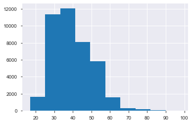

```python
data["age"].hist()
```

Como se puede observar, la variable edad presenta valores con un rango entre 17 y 98, por otra parte, la media es 40 años, por tanto, parece ser que no hay datos "raros"

## Variable job (trabajo)

```python
## Frecuencia absoluta
pd.value_counts(data['job'])
```

```
admin.           10422
blue-collar       9254
technician        6743
services          3969
management        2924
retired           1720
entrepreneur      1456
self-employed     1421
housemaid         1060
unemployed        1014
student            875
unknown            330
Name: job, dtype: int64
```

```python
## Frecuencia relativa
100 * data['job'].value_counts() / len(data['job'])
```

```
admin.           25.303486
blue-collar      22.467709
technician       16.371273
services          9.636302
management        7.099155
retired           4.175974
entrepreneur      3.535010
self-employed     3.450034
housemaid         2.573565
unemployed        2.461882
student           2.124405
unknown           0.801204
Name: job, dtype: float64
```

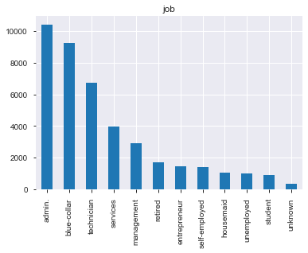

```python
plot_frec_abs = data['job'].value_counts().plot(kind='bar', title='job')
```

Se puede observar que la variable trabajo presenta una categorìa denominada "unknown", que corresponde al 0,8% , por lo tanto, se procede a eliminar esta categoría.

```python
data=data[data.job!="unknown"]
```

## Variable marital (estado civil)

```python
## Frecuencia absoluta
pd.value_counts(data['marital'])
```

```
married     24694
single      11494
divorced     4599
unknown        71
Name: marital, dtype: int64
```

```python
## Frecuencia relativa
100 * data['marital'].value_counts() / len(data['marital'])
```

```
married     60.438592
single      28.131578
divorced    11.256058
unknown      0.173773
Name: marital, dtype: float64
```

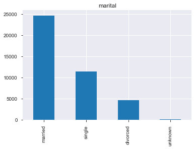

```python
plot_frec_abs = data['marital'].value_counts().plot(kind='bar', title='marital')
```

```python
data=data[data.job!="unknown"]
```

## Variable education (educación)

```python
## Frecuencia absoluta
pd.value_counts(data['education'])
```

```
university.degree      12123
high.school             9478
basic.9y                6014
professional.course     5231
basic.4y                4124
basic.6y                2270
unknown                 1600
illiterate                18
Name: education, dtype: int64
```

```python
## Frecuencia relativa
100 * data['education'].value_counts() / len(data['education'])
```

```
university.degree      29.671056
high.school            23.197415
basic.9y               14.719272
professional.course    12.802878
basic.4y               10.093495
basic.6y                5.555828
unknown                 3.916002
illiterate              0.044055
Name: education, dtype: float64
```

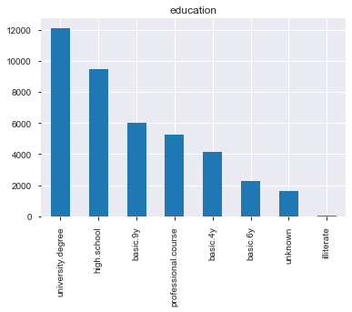

```python
plot_frec_abs = data['education'].value_counts().plot(kind='bar', title='education')
```

Se procede a eliminar la categorìa unknown de la variable education.

```python
data=data[data.education!="unknown"]
```

### Variable default, si tiene o no tiene mora

```python
## Frecuencia absoluta
pd.value_counts(data['default'])
```

```
no         31284
unknown     7971
yes            3
Name: default, dtype: int64
```

Esta variable no se debe utilizará para el análisis. ¿Por qué?

### Variable housing (si tiene o no vivienda)

```python
## Frecuencia absoluta
pd.value_counts(data['housing'])
```

```
yes        20605
no         17706
unknown      947
Name: housing, dtype: int64
```

```python
## Frecuencia relativa
100 * data['housing'].value_counts() / len(data['housing'])
```

```
yes        52.486117
no         45.101635
unknown     2.412247
Name: housing, dtype: float64
```

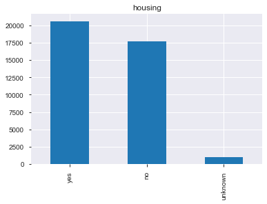

```python
plot_frec_abs = data['housing'].value_counts().plot(kind='bar', title='housing')
```

Se procede a eliminar la categorìa unknown de la variable housing.

```python
data=data[data.housing!="unknown"]
```

## Variable loan (si tiene o no prestamo)

```python
## Frecuencia absoluta
pd.value_counts(data['loan'])
```

```
no     32344
yes     5967
Name: loan, dtype: int64
```

```python
## Frecuencia relativa
100 * data['loan'].value_counts() / len(data['loan'])
```

```
no     84.424839
yes    15.575161
Name: loan, dtype: float64
```

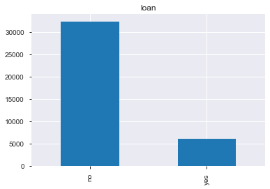

```python
plot_frec_abs = data['loan'].value_counts().plot(kind='bar', title='loan')
```

## Variables excluidas para la limpieza de los datos

Las siguientes variables fueron excludías del análisis month (mes) y duration (duración de la llamada), campaign ¿Por qué?

## variable contact (ipo de contacto)

```python
## Frecuencia absoluta
pd.value_counts(data['contact'])
```

```
cellular     24487
telephone    13824
Name: contact, dtype: int64
```

```python
## Frecuencia relativa
100 * data['contact'].value_counts() / len(data['contact'])
```

```
cellular     63.916369
telephone    36.083631
Name: contact, dtype: float64
```

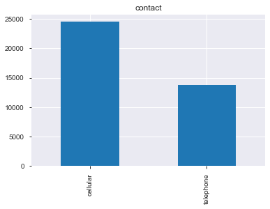

```python
plot_frec_abs = data['contact'].value_counts().plot(kind='bar', title='contact')
```

## Variable pdays (dìas transcurridos desde el ùltimo contacto )

```python
data["pdays"].describe()
```

```
count    38311.000000
mean       963.463496
std        184.464747
min          0.000000
25%        999.000000
50%        999.000000
75%        999.000000
max        999.000000
Name: pdays, dtype: float64
```

Como s puede observar, esta variable es numérica, sin embargo, 999 es un valor que indica que el cliente nunca ha sido contactado, por otra parte, por lo menos el 75 % de los datos indican que los clientes nunca se han tocado ppreviamente, por tanto, no se utilizará esta variable para un futuro análisis, sin embargo, se utilizará la variable previous, que indica la cantidad de veces que se han contactado con el cliente previamente.

## Variable previous (número de contactos previos al cliente antes de la campaña)

```python
data["previous"].describe()
```

```
count    38311.000000
mean         0.170291
std          0.487404
min          0.000000
25%          0.000000
50%          0.000000
75%          0.000000
max          7.000000
Name: previous, dtype: float64
```

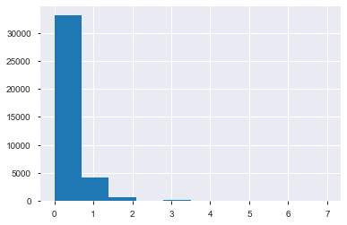

```python
data["previous"].hist()
```

## Variable poutcome (la campaña anterior fue exitosa o no)

```python
## Frecuencia absoluta
pd.value_counts(data['poutcome'])
```

```
nonexistent    33114
failure         3949
success         1248
Name: poutcome, dtype: int64
```

```python
## Frecuencia relativa
100 * data['poutcome'].value_counts() / len(data['poutcome'])
```

```
nonexistent    86.434705
failure        10.307745
success         3.257550
Name: poutcome, dtype: float64
```

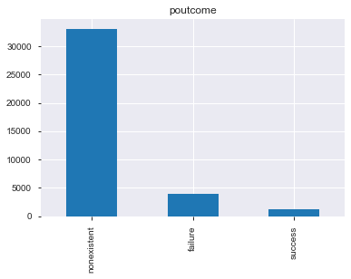

```python
plot_frec_abs = data['poutcome'].value_counts().plot(kind='bar', title='poutcome')
```

## Variable target

```python
## Frecuencia absoluta
pd.value_counts(data['y'])
```

```
no     34044
yes     4267
Name: y, dtype: int64
```

```python
## Frecuencia relativa
100 * data['y'].value_counts() / len(data['y'])
```

```
no     88.862207
yes    11.137793
Name: y, dtype: float64
```

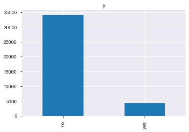

```python
plot_frec_abs = data['y'].value_counts().plot(kind='bar', title='y')
```

### Selección de variables para el análisis.

```python
data_analisis=data.loc[:, ['age',
'job',
'marital',
'education',
'housing',
'loan',
'contact',
'previous',
'poutcome',
'y']]
```

## Discretización de la variable edad.

```python
###Función que permite discretizar una variable cuantitativa
def cate(x):
    if x['age']<=32:
        return '32'
    elif x['age']>32 and x['age']<=38:
        return '33-38'
    elif x['age']>38 and x['age']<=47:
        return '38-47'
    elif x['age']>47 and x['age']<=60:
        return '47-60'
    else:
        return '60'

##Crear una nueva variable denominada "grupo_edad"
data_analisis['grupo_edad']=data_analisis.apply(cate,axis=1)
```

```python
##Frecuencia absoluta
pd.value_counts(data_analisis['grupo_edad'])
```

```
32       10517
33-38     9462
38-47     9372
47-60     8180
60         780
Name: grupo_edad, dtype: int64
```

```python
## Frecuencia relativa
100 * data_analisis['grupo_edad'].value_counts() / len(data_analisis['grupo_edad'])
```

```
32       27.451646
33-38    24.697867
38-47    24.462948
47-60    21.351570
60        2.035969
Name: grupo_edad, dtype: float64
```

A continuación, se construye una tabla de contigencia entre la variable grupo edad y la variable y

```python
Tabla = pd.crosstab(index=data_analisis.grupo_edad,columns=data_analisis["y"],margins=True)
Tabla.index= ["32","33-38", "38-47", "47-60", "60", "Total y"] # Para las filas, pero el último elemento es el total de la "columna"
Tabla.columns= ["no", 'yes', "Total_edad"] # Para las columnas, pero el último elemento es el total de la "fila"
Tabla
```

|  | no | yes | Total_edad |
| --- | --- | --- | --- |
| 32 | 9123 | 1394 | 10517 |
| 33-38 | 8508 | 954 | 9462 |
| 38-47 | 8645 | 727 | 9372 |
| 47-60 | 7339 | 841 | 8180 |
| 60 | 429 | 351 | 780 |
| Total y | 34044 | 4267 | 38311 |

```python
####Frecuencia relativa filas
table2 = Tabla.div(Tabla.Total_edad, axis=0)
table2
```

|  | no | yes | Total_edad |
| --- | --- | --- | --- |
| 32 | 0.867453 | 0.132547 | 1.0 |
| 33-38 | 0.899176 | 0.100824 | 1.0 |
| 38-47 | 0.922429 | 0.077571 | 1.0 |
| 47-60 | 0.897188 | 0.102812 | 1.0 |
| 60 | 0.550000 | 0.450000 | 1.0 |
| Total y | 0.888622 | 0.111378 | 1.0 |

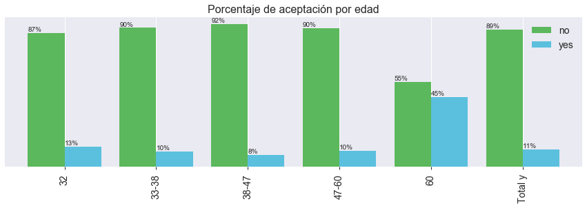

```python
colors_list = ['#5cb85c','#5bc0de','#d9534f']

# Change this line to plot percentages instead of absolute values
ax = (table2[["no", "yes"]]).plot(kind='bar',figsize=(15,4),width = 0.8,color = colors_list,edgecolor=None)
plt.legend(labels=Tabla.columns,fontsize= 14)
plt.title("Porcentaje de aceptación por edad",fontsize= 16)

plt.xticks(fontsize=14)
for spine in plt.gca().spines.values():
    spine.set_visible(False)
plt.yticks([])

# Add this loop to add the annotations
for p in ax.patches:
    width, height = p.get_width(), p.get_height()
    x, y = p.get_xy()
    ax.annotate('{:.0%}'.format(height), (x, y + height + 0.01))
```

## Qué conclusiones y que acciones puede obtener del gráfico anterior?

Se pede pensar en realizar una campaña enfocada a las personas mayor a 60 años.

## Análisis con relación a la variable job

```python
Tabla = pd.crosstab(index=data_analisis.job,columns=data_analisis["y"],margins=True)
Tabla.index= ['admin',
'blue-collar',
'entrepreneur',
'housemaid',
'management',
'retired',
'self-employed',
'services',
'student',
'technician',
'unemployed', "Total y"] # Para las filas, pero el último elemento es el total de la "columna"
Tabla.columns= ["no", 'yes', "Total_job"] # Para las columnas, pero el último elemento es el total de la "fila"
Tabla
```

|  | no | yes | Total_job |
| --- | --- | --- | --- |
| admin | 8666 | 1285 | 9951 |
| blue-collar | 7973 | 598 | 8571 |
| entrepreneur | 1246 | 117 | 1363 |
| housemaid | 892 | 98 | 990 |
| management | 2427 | 304 | 2731 |
| retired | 1191 | 391 | 1582 |
| self-employed | 1208 | 146 | 1354 |
| services | 3424 | 297 | 3721 |
| student | 481 | 208 | 689 |
| technician | 5706 | 685 | 6391 |
| unemployed | 830 | 138 | 968 |
| Total y | 34044 | 4267 | 38311 |

```python
####Frecuencia relativa filas
table2 = Tabla.div(Tabla.Total_job, axis=0)
table2
```

|  | no | yes | Total_job |
| --- | --- | --- | --- |
| admin | 0.870867 | 0.129133 | 1.0 |
| blue-collar | 0.930230 | 0.069770 | 1.0 |
| entrepreneur | 0.914160 | 0.085840 | 1.0 |
| housemaid | 0.901010 | 0.098990 | 1.0 |
| management | 0.888685 | 0.111315 | 1.0 |
| retired | 0.752845 | 0.247155 | 1.0 |
| self-employed | 0.892171 | 0.107829 | 1.0 |
| services | 0.920183 | 0.079817 | 1.0 |
| student | 0.698113 | 0.301887 | 1.0 |
| technician | 0.892818 | 0.107182 | 1.0 |
| unemployed | 0.857438 | 0.142562 | 1.0 |
| Total y | 0.888622 | 0.111378 | 1.0 |

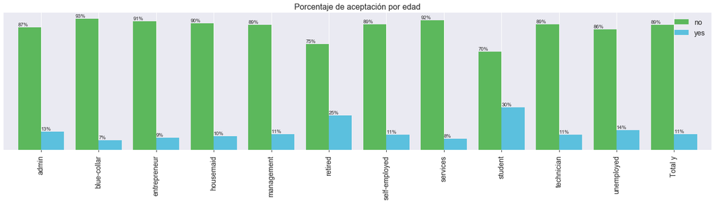

```python
colors_list = ['#5cb85c','#5bc0de','#d9534f']

# Change this line to plot percentages instead of absolute values
ax = (table2[["no", "yes"]]).plot(kind='bar',figsize=(25,5),width = 0.8,color = colors_list,edgecolor=None)
plt.legend(labels=Tabla.columns,fontsize= 14)
plt.title("Porcentaje de aceptación por edad",fontsize= 16)

plt.xticks(fontsize=14)
for spine in plt.gca().spines.values():
    spine.set_visible(False)
plt.yticks([])

# Add this loop to add the annotations
for p in ax.patches:
    width, height = p.get_width(), p.get_height()
    x, y = p.get_xy()
    ax.annotate('{:.0%}'.format(height), (x, y + height + 0.01))
```

## Qué conclusiones y que acciones puede obtener del gráfico anterior?

Se puede pensar en realziar campañas enfocadas hacia los estudiantes y los retirados.

## Análisis con relación a la variable tipo de contacto (contact)

```python
Tabla = pd.crosstab(index=data_analisis.contact,columns=data_analisis["y"],margins=True)
Tabla.index= ["cellular","telephone", "Total y"] # Para las filas, pero el último elemento es el total de la "columna"
Tabla.columns= ["no", 'yes', "Total_contact"] # Para las columnas, pero el último elemento es el total de la "fila"
Tabla
```

|  | no | yes | Total_contact |
| --- | --- | --- | --- |
| cellular | 20943 | 3544 | 24487 |
| telephone | 13101 | 723 | 13824 |
| Total y | 34044 | 4267 | 38311 |

```python
####Frecuencia relativa filas
table2 = Tabla.div(Tabla.Total_contact, axis=0)
table2
```

|  | no | yes | Total_contact |
| --- | --- | --- | --- |
| cellular | 0.855270 | 0.144730 | 1.0 |
| telephone | 0.947700 | 0.052300 | 1.0 |
| Total y | 0.888622 | 0.111378 | 1.0 |

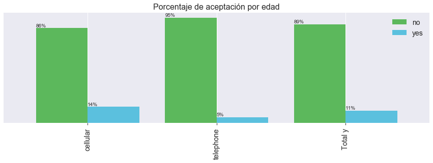

```python
colors_list = ['#5cb85c','#5bc0de','#d9534f']

# Change this line to plot percentages instead of absolute values
ax = (table2[["no", "yes"]]).plot(kind='bar',figsize=(15,4),width = 0.8,color = colors_list,edgecolor=None)
plt.legend(labels=Tabla.columns,fontsize= 14)
plt.title("Porcentaje de aceptación por edad",fontsize= 16)

plt.xticks(fontsize=14)
for spine in plt.gca().spines.values():
    spine.set_visible(False)
plt.yticks([])

# Add this loop to add the annotations
for p in ax.patches:
    width, height = p.get_width(), p.get_height()
    x, y = p.get_xy()
    ax.annotate('{:.0%}'.format(height), (x, y + height + 0.01))
```

## Qué conclusiones y que acciones puede obtener del gráfico anterior?

Se puede pensar en realziar campañas enfocadas hacia los clientes que tienen celular. Por telefono nno responden mucho.

## Análisis con relación a la variable loan (si tiene crédito o no)

```python
Tabla = pd.crosstab(index=data_analisis.loan,columns=data_analisis["y"],margins=True)
Tabla.index= ["no","yes", "Total y"] # Para las filas, pero el último elemento es el total de la "columna"
Tabla.columns= ["no", 'yes', "Total_loan"] # Para las columnas, pero el último elemento es el total de la "fila"
Tabla
```

|  | no | yes | Total_loan |
| --- | --- | --- | --- |
| no | 28716 | 3628 | 32344 |
| yes | 5328 | 639 | 5967 |
| Total y | 34044 | 4267 | 38311 |

```python
####Frecuencia relativa filas
table2 = Tabla.div(Tabla.Total_loan, axis=0)
table2
```

|  | no | yes | Total_loan |
| --- | --- | --- | --- |
| no | 0.887831 | 0.112169 | 1.0 |
| yes | 0.892911 | 0.107089 | 1.0 |
| Total y | 0.888622 | 0.111378 | 1.0 |

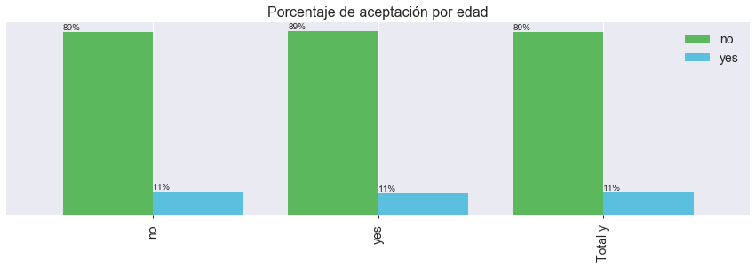

```python
colors_list = ['#5cb85c','#5bc0de','#d9534f']

# Change this line to plot percentages instead of absolute values
ax = (table2[["no", "yes"]]).plot(kind='bar',figsize=(15,4),width = 0.8,color = colors_list,edgecolor=None)
plt.legend(labels=Tabla.columns,fontsize= 14)
plt.title("Porcentaje de aceptación por edad",fontsize= 16)

plt.xticks(fontsize=14)
for spine in plt.gca().spines.values():
    spine.set_visible(False)
plt.yticks([])

# Add this loop to add the annotations
for p in ax.patches:
    width, height = p.get_width(), p.get_height()
    x, y = p.get_xy()
    ax.annotate('{:.0%}'.format(height), (x, y + height + 0.01))
```

Analizando el gráfico anterior, se puede observar que la variable loan no influye sobre el porcentaje de aceptación a la campaña.